# MA710 - New York Times Articles - Data Science

### Evaluation: check documents

We will have a look at the first 10 of the articles in Cluster 2.

```
##  [1] "The airline offered a refund to every passenger on the flight from which a man was dragged on Sunday, and the Chicago Aviation Department placed two more officers on leave."
##  [2] "United Airlines Chief Executive Officer Oscar Munoz on Tuesday issued an apology for the treatment of a passenger dragged from aboard one of its flights before takeoff on Sunday."
##  [3] "Oscar Munoz, CEO of United Airlines' parent company, sent employees a letter Tuesday that was more contrite than his statement a day earlier about a passenger being dragged from a plane at Chicago's O'Hare International Airport."
##  [4] "United Airlines has released four official statements in response to the backlash against the company since a customer was dragged from an oversold flight Sunday evening at Chicago's O'Hare International Airport."
##  [5] "United Airlines has released four official statements in response to the backlash against the company since a customer was dragged from an oversold flight Sunday evening at Chicago's O'Hare International Airport."
##  [6] "Oscar Munoz, CEO of United Airlines' parent company, has released three written statements in response to the backlash against the company since a customer was dragged from an oversold flight Sunday evening at Chicago's O'Hare International Airport."
##  [7] "Below is the text of the letter United Airlines' parent company CEO Oscar Munoz sent to employees after a passenger was dragged from a United plane at Chicago's O'Hare International Airport. The summary below the letter was compiled by United:"
##  [8] "Images of a bloodied man being forcibly removed from a United Airlines flight in Chicago drew widespread condemnation in China, where state media fueled the public's anger with reports that noted the unidentified victim was an \"Asian passenger.\""
##  [9] "A day after viral videos of a bloodied man being dragged off an overbooked United Express flight at Chicago's O'Hare International Airport by aviation security fueled criticism of the airline, Twitter users poked fun at the airline's tactics."
## [10] "The Latest on the removal of a passenger was dragged off a United Express flight in Chicago (all times local):"
```

And we could also take a look at the first 10 of the articles in Cluster 3:

```
##  [1] "Viola Davis has collected a pile of awards for Fences and is expected to win an Oscar, too. Yet her contenders remain upbeat. They have their reasons."
##  [2] "Taylor Sheridan, 47, quit his journeyman acting career and moved to Wyoming. He is now an Oscar nominee."
##  [3] "Philipp Plein comes to New York, Proenza Schouler says farewell, and new designers debut at Oscar de la Renta."
##  [4] "For documentaries, original songs boost the chances of taking home an Oscar  and may bring more attention to a movie than any award can."
##  [5] "A three-time Oscar-winning cinematographer is being honored by the George Eastman Museum in Rochester, New York, for his work with such Hollywood icons as Francis Ford Coppola and Warren Beatty."
##  [6] "The program, Making Faces on Film, kicks off with a 1925 film by Oscar Micheaux featuring Paul Robeson in two roles."
##  [7] "A spokeswoman for the PwC auditing firm says the company has hired protection for the two accountants responsible for the best-picture flub at the Oscars."
##  [8] "PwC accountants won't be allowed to have their cellphones backstage during future Oscar telecasts."
##  [9] "The accountancy firm behind the biggest blunder in Oscar history  is staying in the picture."
## [10] "Viola Davis won her first Oscar on Sunday for her supporting role as a long-suffering housewife in the African-American family drama \"Fences.\""
```

From the documents check, we could conclude that the topic of cluster 3 is the Oscar nomination of 2017. It mathches the clustering result very well.

We could conclude that the clustering method works well for our clusters. We could define the topic of each clusters by simply looking at the top words or common words of the clusters.

# Base investigation - Iteration 6

The next parameter setting we want to adjust is the stop word to improve our clustering results. Since from our previous step of inverstigation 5, there are some words in common in each cluster. For instance, words “year”, “will”, “said” and “one” don’t really tell the main topics of that cluster. We want to eliminate those words and investigate whether the clustering results can be further improved.

[output not shown]

```r
docs = article.df$lead_paragraph
docs.clean = clean.documents(docs)
docs.sns =
  modify.words(
    docs.clean,
    stem.words=FALSE,  # OPTION: TRUE or FALSE
    ngram.vector=1:3, # OPTION: n-gram lengths
    stop.words=       # OPTION: stop words
      c(stopwords(kind="english"), stopwords(kind="SMART")
      )
  )

doc.matrix <-
  create_matrix(docs.sns,
                language="english",      # Do not change
                stemWords=FALSE,         # Do not change
                removePunctuation=FALSE, # Do not change
                weighting=tm::weightTf   # OPTION: weighting (see below)
  )

dtm = as.matrix(doc.matrix)
dtm=reduce.dtm(dtm,freq.threshold=3)
```

The four clusters are still applied and the clustering results are shown below.

```r
k = 4
set.seed(127)
cluster = kmeans(dtm,k)$cluster
```

### Evaluation: cluster counts

The table below indicates the number of articles that are contained in each cluster.

```
##   cluster Freq
## 1       1  841
## 2       2  229
## 3       3    3
## 4       4  137
```

### Evaluation: common words

We will explore the most common words in each of the clusters and whether we can determine a genral topic for the given clusters.

```
##             word        avg                 word       avg
## 1    [cluster 1]         NA          [cluster 2]        NA
## 2  [841 records]         NA        [229 records]        NA
## 3           year 0.05707491                oscar 0.7729258
## 4            day 0.05588585                trump 0.2882096
## 5         awards 0.05231867            president 0.2838428
## 6         season 0.04994055               donald 0.2532751
## 7         united 0.04994055          donaldtrump 0.2532751
## 8        academy 0.04756243      presidentdonald 0.1703057
## 9           city 0.04637337 presidentdonaldtrump 0.1703057
## 10         night 0.04518430               sunday 0.1572052
## 11        sunday 0.04518430            nominated 0.1484716
## 12        oscars 0.04042806               awards 0.1397380
##                       word avg          word        avg
## 1              [cluster 3]  NA   [cluster 4]         NA
## 2              [3 records]  NA [137 records]         NA
## 3                  academy   1          film 0.94160584
## 4            academyawards   1        awards 0.31386861
## 5     academyawardsbotched   1         oscar 0.29927007
## 6               accountant   1       academy 0.16058394
## 7        accountantacademy   1      director 0.15328467
## 8  accountantacademyawards   1     hollywood 0.14598540
## 9               announcing   1          land 0.11678832
## 10         announcingoscar   1      festival 0.10948905
## 11  announcingoscarpicture   1        laland 0.10948905
## 12                  awards   1        sunday 0.09489051
```

### Evaluation: check documents

We will have a look at the first 10 of the articles in Cluster 2.

```
##  [1] "Viola Davis has collected a pile of awards for Fences and is expected to win an Oscar, too. Yet her contenders remain upbeat. They have their reasons."
##  [2] "Taylor Sheridan, 47, quit his journeyman acting career and moved to Wyoming. He is now an Oscar nominee."
##  [3] "Philipp Plein comes to New York, Proenza Schouler says farewell, and new designers debut at Oscar de la Renta."
##  [4] "For documentaries, original songs boost the chances of taking home an Oscar  and may bring more attention to a movie than any award can."
##  [5] "A three-time Oscar-winning cinematographer is being honored by the George Eastman Museum in Rochester, New York, for his work with such Hollywood icons as Francis Ford Coppola and Warren Beatty."
##  [6] "The former world champion boxer said using an image of a wall to promote a bout between two fighters of Mexican descent was a direct hit to Donald Trump."
##  [7] "PwC accountants won't be allowed to have their cellphones backstage during future Oscar telecasts."
##  [8] "The accountancy firm behind the biggest blunder in Oscar history  is staying in the picture."
##  [9] "Viola Davis won her first Oscar on Sunday for her supporting role as a long-suffering housewife in the African-American family drama \"Fences.\""
## [10] "A portrait of Oscar Wilde that once hung above the writer's fireplace has gone on display at London's Tate Britain gallery along with the door to Wilde's prison cell."
```

Clearly, the articles mentioned Academy Awards. The topic results truley reflect the core information of articles in that cluster, which means that the clustering results are useful.

And we could also take a look at the first 10 of the articles in Cluster 3:

```
##  [1] "An accountant for the Academy Awards botched the meticulous procedure for announcing the Oscar for best picture when he handed victory to \"La La Land\" before declaring \"Moonlight\" the real winner, PricewaterhouseCoopers (PwC) said on Monday."
##  [2] "An accountant for the Academy Awards botched the meticulous procedure for announcing the Oscar for best picture when he handed victory to \"La La Land\" before declaring \"Moonlight\" the real winner, PricewaterhouseCoopers (PwC) said on Monday."
##  [3] "An accountant for the Academy Awards botched the meticulous procedure for announcing the Oscar for best picture when he handed victory to \"La La Land\" before declaring \"Moonlight\" the real winner, PricewaterhouseCoopers (PwC) said on Monday."
##  [4] NA
##  [5] NA
##  [6] NA
##  [7] NA
##  [8] NA
##  [9] NA
## [10] NA
```

We can also take look at the first 10 articles in Cluster 4:

```
##  [1] "A preview of the film."
##  [2] "The program, Making Faces on Film, kicks off with a 1925 film by Oscar Micheaux featuring Paul Robeson in two roles."
##  [3] "The president of the film academy has sent an email to its members telling them they have much to be proud of after this year's Oscars ceremony, and reassuring them changes will be made to avoid a repeat of problems like the botched best-picture announcement that closed the show."
##  [4] "Two Iranian hard-line newspapers have criticized Asghar Farhadi's best foreign film Oscar, claiming \"politics\" brought him the award."
##  [5] "The president of the film academy says the two accountants responsible for the best-picture flub at Sunday's Academy Awards will never work the Oscars again. She also laments that the error overshadowed a show that celebrated a rich diversity of talent and storytelling."
##  [6] "Oscar winning film \"Moonlight\" presents a view of Miami that never shows up in a tourism video. Far from the sun and glamour of South Beach or the artists and hipsters of Wynwood, it shows predominantly black communities, truly known by few outside the people who live there."
##  [7] "This year's Academy Awards are behind us, but J.J. Abrams already has predicted Mark Hamill will be in the running for an Oscar next year for his turn as Luke Skywalker in the next Star Wars film."
##  [8] "Animal cartoon \"Zootopia,\" an exploration of bias through the comedic story of a bunny who becomes a police officer, won the Academy Award on Sunday for best animated feature film."
##  [9] "The Oscar for Asghar Farhadi's \"The Salesman\" energized many of the filmmaker's fellow Iranians, who saw the win for best foreign film Monday as a pointed rebuke to the Trump administration and its efforts to deny them entry into the U.S."
## [10] "Iran's \"The Salesman,\" a drama about honor and revenge in a modern marriage, won the Oscar on Sunday for best foreign language film."
```

The articles are about the Oscar awards and ceremony. The main topic is picked by our clustering topic result. All in all, the clustering topic results match the actual articles meaning. The clustering results are effective in capturing different topics about Oscar.

# Word Cloud of each cluster

We could use common words by frequency to visualize each cluster.

Firstly, we need to construct a data frame of common word and frequency of each cluster:

```r
cluster_matrix <- check.clusters(cluster, 1)[c(-1,-2),]
col <- c("word1", "freq1", "word2", "freq2", "word3", "freq3", "word4", "freq4")
colnames(cluster_matrix) <- col
cluster_matrix
```

```
##      word1      freq1                word2     freq2
## 3     year 0.05707491                oscar 0.7729258
## 4      day 0.05588585                trump 0.2882096
## 5   awards 0.05231867            president 0.2838428
## 6   season 0.04994055               donald 0.2532751
## 7   united 0.04994055          donaldtrump 0.2532751
## 8  academy 0.04756243      presidentdonald 0.1703057
## 9     city 0.04637337 presidentdonaldtrump 0.1703057
## 10   night 0.04518430               sunday 0.1572052
## 11  sunday 0.04518430            nominated 0.1484716
## 12  oscars 0.04042806               awards 0.1397380
##                      word3 freq3     word4      freq4
## 3                  academy     1      film 0.94160584
## 4            academyawards     1    awards 0.31386861
## 5     academyawardsbotched     1     oscar 0.29927007
## 6               accountant     1   academy 0.16058394
## 7        accountantacademy     1  director 0.15328467
## 8  accountantacademyawards     1 hollywood 0.14598540
## 9               announcing     1      land 0.11678832
## 10         announcingoscar     1  festival 0.10948905
## 11  announcingoscarpicture     1    laland 0.10948905
## 12                  awards     1    sunday 0.09489051
```

We could build a word cloud based on the frequency: We use `brewer.pal` function to create valid color schemes for th words.

### Word Cloud of cluster 1:

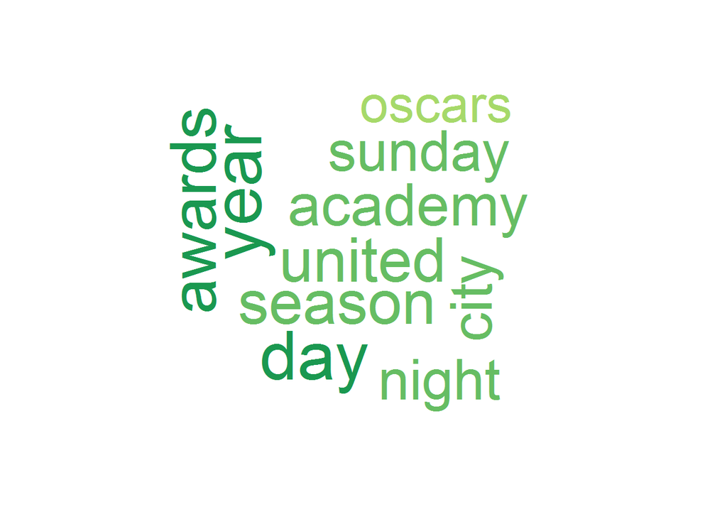

```r
library(wordcloud)
library(RColorBrewer)
pal <- brewer.pal(9, "RdYlGn")
wordcloud(cluster_matrix$word1, cluster_matrix$freq1, colors=pal , rot.per=.3)
```

### Word Cloud of cluster 2:

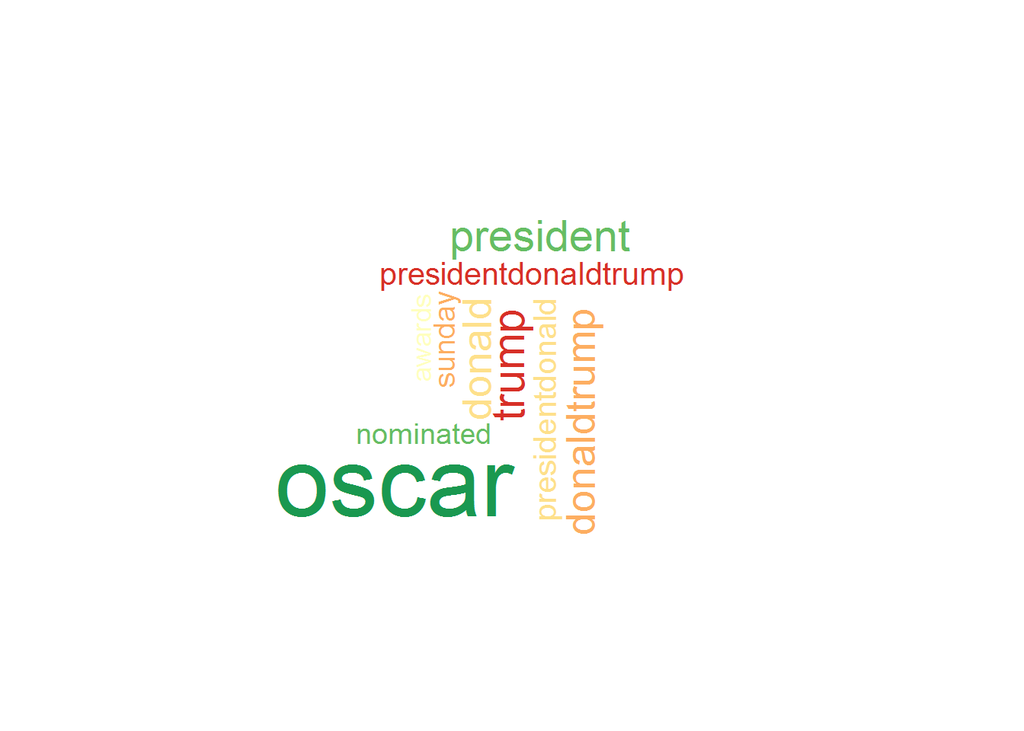

```r
library(wordcloud)
library(RColorBrewer)
wordcloud(cluster_matrix$word2, cluster_matrix$freq2, colors=pal, random.color=TRUE, rot.per=.5)
```

### Word Cloud of cluster 3:

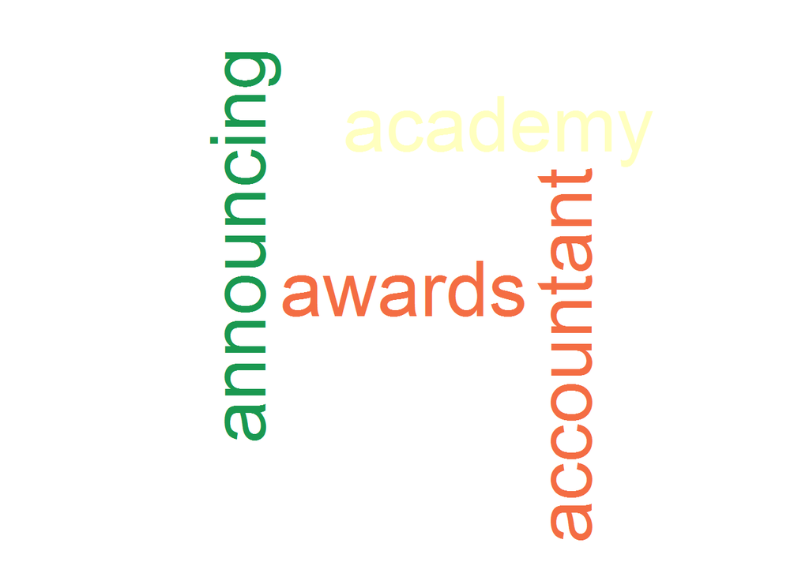

```r
library(wordcloud)
library(RColorBrewer)
wordcloud(cluster_matrix$word3, cluster_matrix$freq3, colors=pal, random.color=TRUE, rot.per=.4)
```

### Word Cloud of cluster 4:

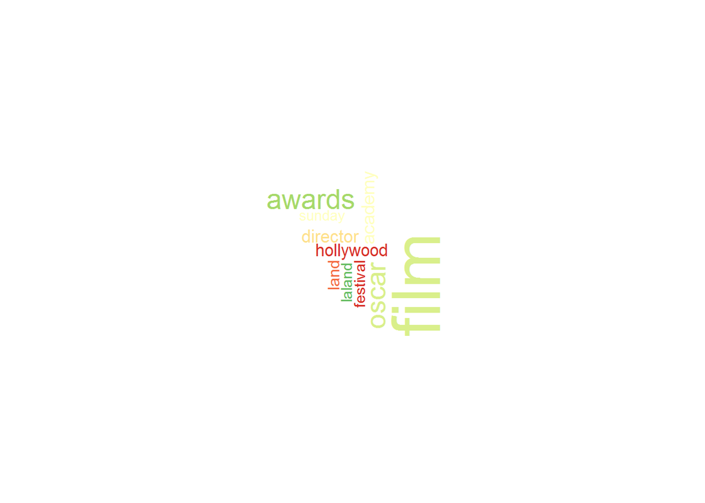

```r
wordcloud(cluster_matrix$word4, cluster_matrix$freq4, colors=pal, random.color=TRUE, rot.per=.5)
```

# Conclusion